# Section 5 MatchAlign

2022-06-24

## Data

We load the main packages, including the R package $\texttt{infinitefactor}$ that we developed.

```r
rm(list = ls())
set.seed(1)
library(tidyverse)
library(infinitefactor)
library(coda)
library(factor.switching)
library(dplyr)
library(lavaan)
```

```r
source("helper_fcts.R")
```

We consider here the two applications from Section 4 of the paper. The first concerns the measurements of $p=9$ mental ability test scores of $n=145$ seventh and eighth-grade students from the Grant-White School in Chicago (GrantWhite). In the second, we use data from the National Health and Nutrition Examination Survey (NHANES) collected in 2015 and 2016. For NHANES, we select a subset of $107$ chemical exposures for which at least $30\%$ of measurements have been recorded (i.e., are not missing). We also select a subsample of $4468$ individuals for which at least $30\%$ of the $107$ chemicals have been recorded. After this preprocessing step, we are left with a matrix $X$ of dimension $4468 \times 107$ with $36\%$ missing data.

```r
which_data = 'NHANES' # %in% c('NHANES','GrantWhite')

if(which_data=='NHANES'){

  df <- readRDS("df_chem.rds")
  dim(df)

  k <- 25

} else if (which_data=='GrantWhite'){

  df <- HolzingerSwineford1939
  df <- df[df$school=="Grant-White",]
  df <- df %>% select(matches("^x\\d+$"))
  dim(df)

  k <- 3

} else {
  stop("Choose 'which_data' among c('NHANES','Grant-White')")
}
```

```r
df[1:10,1:7]
```

```
##    LBXBCR LBXBCO  LBXCOT  LBXHCT  URXCOTT  URXHCTT  URDTNE2
## 1    0.29   0.19   0.011   0.011    0.124 1.84e-01   0.0017
## 2    0.29   0.12 281.000 299.000 6180.000 2.24e+04 151.6000
## 3    0.29   0.15   0.672   0.417    6.310 1.82e+01   0.1305
## 7    0.29   0.10   0.162   0.113       NA       NA       NA
## 8    0.29   0.15 201.000  34.000 3970.000 3.42e+03  40.3200
## 12   0.29   0.14   0.011   0.011    0.072 1.52e-01   0.0012
## 15   0.29   0.16   0.015   0.011    0.137 3.03e-01   0.0024
## 18   2.52   0.12   0.046   0.019       NA       NA       NA
## 20     NA     NA      NA      NA    0.064 1.47e-01   0.0011
## 21   0.29   0.17   0.011   0.011    0.199 2.66e-01   0.0025
```

After pre-processing the data, some of the observations might still be missing (more than $35\%$ in NHANES).

```r
is.na(df) %>% mean()
```

```
## [1] 0.3684937
```

```r
cor_X <- cor(df, use = "pairwise.complete.obs")
res <- eigen(cor_X)
idx_pos <- res$values>0
eig_cumsum <- cumsum(res$values[idx_pos])/sum(res$values[idx_pos])
round( eig_cumsum[k] * 100, 2 )
```

```
## [1] 63.88
```

## MSGP prior

We now estimate a Bayesian factor model using the MSGP prior, with with $k$ latent variables.

We modified the function $\texttt{linear_MSGP}$ contained in the $\texttt{infinitefactor}$ package in order to deal with missing data. The new function $\texttt{linear_MSGP_NA}$ is contained in the file $\texttt{helper_fcts.R}$.

Missing data inputation is straightforward in Bayesian factor model. Given the values of $\Lambda$, $\{\eta_i\}_{i=1}^n$, and $\Sigma=\text{diag}(\sigma_1^2,\dots,\sigma_p^2)$ at each iteration of the MCMC chain, any missing entry $X_{ij}$ is sampled as
$$X_{i j} \sim N(\lambda_j^\top \eta_i,
\sigma_j^2)$$
where $\lambda_j$ is the $j^{th}$ row of $\Lambda$.

```r
out <- linearMGSP_NA(log(df) %>% as.matrix() %>% scale(), verbose = F,
                     nrun = 10000, burn = 5000, thin = 5,
                     kinit = k, adapt = F, output = "factSamples")
```

```r
lambdaSamps <- out$lambdaSamps
etaSamps <- out$etaSamps

lambda_fact_switch <- to_fact_switching(lambdaSamps)
```

## Post-Processing Algorithms

Now we run different post-processing algorithms, comparing MatchAlign RSP and WOP. For each method we also compute also runtimes and ESS.

### WOP

```r
start_time <- Sys.time()
wop_ris <- quiet(weighted_procrustes_switching(lambda_mcmc = lambda_fact_switch, verbose = F,))
end_time <- Sys.time()
WOP_time <- end_time - start_time

Lambda_WOP <- to_infinitefact(wop_ris$lambda_reordered_mcmc, k, ncol(df))

WOP_ess <- apply(simplify2array(Lambda_WOP), c(1,2), effectiveSize) %>% mean()
```

### RSP-full-SA

```r
start_time <- Sys.time()
rspFull_ris <- quiet(rsp_full_sa(lambda_mcmc = lambda_fact_switch, sa_loops = 20, verbose = F))
end_time <- Sys.time()
rspFull_time = end_time - start_time

Lambda_rspFull <- to_infinitefact(rspFull_ris$lambda_reordered_mcmc, k, ncol(df))

rspFull_ess <- apply(simplify2array(Lambda_rspFull), c(1,2), effectiveSize) %>% mean()
```

### RSP-partial-SA

```r
start_time <- Sys.time()
rspPartial_ris <- quiet(rsp_partial_sa(lambda_mcmc = lambda_fact_switch, sa_loops = 20, verbose = F))
end_time <- Sys.time()
rspPartial_time = end_time - start_time

Lambda_rspPartial <- to_infinitefact(rspPartial_ris$lambda_reordered_mcmc, k, ncol(df))

rspPartial_ess <- apply(simplify2array(Lambda_rspPartial), c(1,2), effectiveSize) %>% mean()
```

### MatchAlign

```r
start_time <- Sys.time()
out_MatchAlign <- jointRot_NOnorm(lambdaSamps, etaSamps)
end_time <- Sys.time()

MatchAlign_time = end_time - start_time

Lambda_MatchAlign <- out_MatchAlign$lambda

MAl_ess <- apply(simplify2array(Lambda_MatchAlign), c(1,2), effectiveSize) %>% mean()
```

## Accuracy Metric

We further compute the accuracy metric (3.1):
$$|| \overline{\Lambda\Lambda^T \!\!}\,\, - \bar
\Lambda_* \bar \Lambda_* ^T ||_F$$
where $\overline{\Lambda\Lambda^T \!\!}\,\, = \frac{1}{T}\sum_{t = 1}^T \Lambda^{(t)}(\Lambda^{(t)})^T$ and $\bar \Lambda_* = \frac{1}{T} \sum_{t = 1}^T \Lambda^{(t)}_*$ is the posterior mean of the aligned $\Lambda$.

In order to give a more direct intuition of the effective benefit of each methodology, the metric values are expressed also as percentages of the relative error in the posterior mean of the covariance matrix
$$\frac{ || \overline{\Lambda\Lambda^T \!\!}\,\, -
\bar \Lambda_* \bar \Lambda_*^T ||_F }{|| \overline{\Lambda\Lambda^T
\!\!}\,\,\, ||_F}$$

```r
# samples
Lambda_LambdaT <- lapply(lambdaSamps, function(x) x %*% t(x))
Lambda_LambdaT_mean <- lmean(Lambda_LambdaT)

# Base line
base_norm <- norm(Lambda_LambdaT_mean, type = "F")

# WOP
Align_cov <- lmean(Lambda_WOP)
Align_cov_mean <- Align_cov %*% t(Align_cov)
WOP_norm <- norm(Align_cov_mean - Lambda_LambdaT_mean, type = "F")

# RSP-full-SA
Align_cov <- lmean(Lambda_rspFull)
Align_cov_mean <- Align_cov %*% t(Align_cov)
rspFull_norm <- norm(Align_cov_mean - Lambda_LambdaT_mean, type = "F")

# RSP-partial-SA
Align_cov <- lmean(Lambda_rspPartial)
Align_cov_mean <- Align_cov %*% t(Align_cov)
rspPartial_norm <- norm(Align_cov_mean - Lambda_LambdaT_mean, type = "F")

# MatchAlign
LambdaAL_mean <- lmean(Lambda_MatchAlign)
Align_cov_mean <- LambdaAL_mean %*% t(LambdaAL_mean)
MatchAlign_norm <- norm(Align_cov_mean - Lambda_LambdaT_mean, type = "F")

# Unaligned
Align_cov <- lmean(lambdaSamps)
Align_cov_mean <- Align_cov %*% t(Align_cov)
Unaligned_norm <- norm(Align_cov_mean - Lambda_LambdaT_mean, type = "F")
```

## Runtimes

```r
print('Runtimes')
```

```
## [1] "Runtimes"
```

```r
round(c(MatchAlign = MatchAlign_time, `RSP-full-SA` = rspFull_time,
  `RSP-partial-SA` = rspPartial_time,WOP=WOP_time),3)
```

```
## Time differences in secs
##     MatchAlign    RSP-full-SA RSP-partial-SA            WOP
##         11.602         25.276        578.229          9.570
```

## Accuracy Metric

```r
print('Absolute Accuracy Metric')
```

```
## [1] "Absolute Accuracy Metric"
```

```r
round(c(MatchAlign = MatchAlign_norm, `RSP-full-SA` = rspFull_norm,
  `RSP-partial-SA`=rspPartial_norm, WOP=WOP_norm, Unaligned=Unaligned_norm),3)
```

```
##     MatchAlign    RSP-full-SA RSP-partial-SA            WOP      Unaligned
##          0.013          1.746          0.476          0.010          0.088
```

```r
print('Relative Accuracy Metric')
```

```
## [1] "Relative Accuracy Metric"
```

```r
round(100*c(MatchAlign = MatchAlign_norm, `RSP-full-SA`=rspFull_norm,
            `RSP-partial-SA`=rspPartial_norm, WOP=WOP_norm, Unaligned=Unaligned_norm)/base_norm,1)
```

```
##     MatchAlign    RSP-full-SA RSP-partial-SA            WOP      Unaligned
##            0.4           56.0           15.3            0.3            2.8
```

## ESS

```r
print('Absolute ESS')
```

```
## [1] "Absolute ESS"
```

```r
round(c(MatchAlign=MAl_ess, `RSP-full-SA`=rspFull_ess,
        `RSP-partial-SA`=rspPartial_ess, WOP=WOP_ess),1)
```

```
##     MatchAlign    RSP-full-SA RSP-partial-SA            WOP
##          246.5          975.4          834.7          247.8
```

```r
print('Relative ESS')
```

```
## [1] "Relative ESS"
```

```r
round(100*c(MatchAlign=MAl_ess, `RSP-full-SA`=rspFull_ess,
        `RSP-partial-SA`=rspPartial_ess, WOP=WOP_ess)/length(lambdaSamps),1)
```

```
##     MatchAlign    RSP-full-SA RSP-partial-SA            WOP
##           24.6           97.5           83.5           24.8
```

## Plots

We now plot the matrix of factor loadings after using MatchAlign to post-process the results. We re-arrange the rows of $\Lambda$ to make the plot easier to interpret.

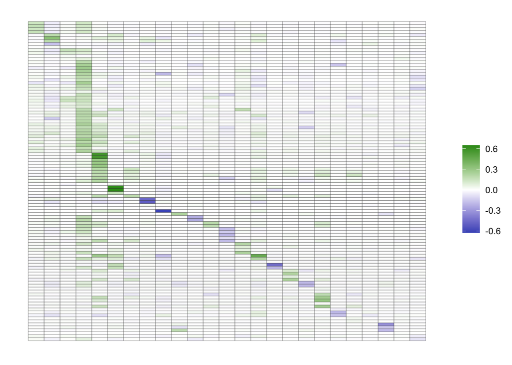

```r
mLambda_plot <- lmean(Lambda_MatchAlign)
ind_max = apply(mLambda_plot %>% abs(), 1, function(x) which(x == max(x))) %>%
  order()

plotmat(mLambda_plot[ind_max,])
```